# ARCH and GARCH Models

Volatility of the Broad Dollar Index and the S&P 500

Published

December 3, 2023

Modified

September 15, 2026

### Purpose

The models in the preceding sections describe the level of a series. This section models its variance. Daily returns on the dollar index are close to unpredictable in sign but not in size: large moves cluster, and a day of large movement is more likely to be followed by another. The ARCH model (Engle 1982) and its generalisation, GARCH (Bollerslev 1986), describe that clustering by letting the conditional variance of the return depend on recent squared returns and on its own past. The section fits a mean equation for the return, tests for ARCH effects in its residuals, compares nine specifications of the variance equation, checks the retained model’s residuals, examines the volatility it estimates over the sample, evaluates its one-day-ahead variance forecasts out of sample against simpler methods, forecasts volatility sixty trading days ahead, and then asks whether the Federal Funds Rate explains any of the volatility, in the variance equation at daily frequency and in the relationship between monthly realised volatility and the policy rate. Estimation uses the `rugarch` package (Galanos 2024).

## Data

The series is `DTWEXBGS`, the nominal broad dollar index, daily from 2 January 2006 to 24 November 2023, an index with January 2006 = 100. The exchange rate is the channel through which the policy rate reaches net exports: higher U.S. rates relative to other countries draw capital in and raise the dollar. This section models the size of the dollar’s daily movements rather than their direction, and the last section before the summary asks what the policy rate contributes to that. It is converted to daily log returns in %, $r_t = 100\,(\log P_t - \log P_{t-1})$, which gives 4,487 returns. The index rose from 101.4 to 120.7 over the sample, with a low of 85.5 in July 2011 and a high of 128.3 in September 2022.

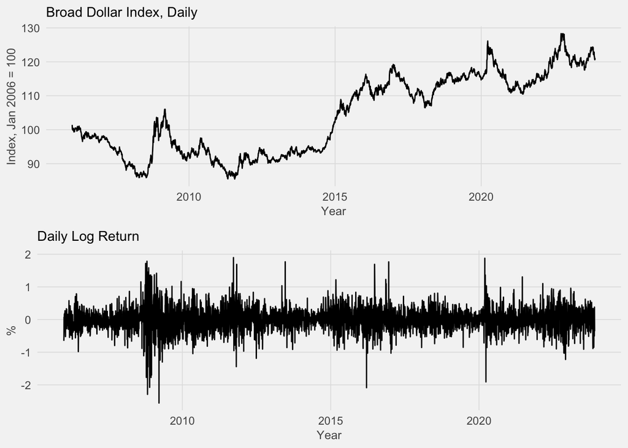

Daily Log Returns, 2006–2023

| Statistic | Value |
| --- | --- |
| Observations | 4,487 |
| Mean, % per day | 0.0039 |
| Standard deviation, % per day | 0.347 |
| Annualised standard deviation, % | 5.51 |
| Skewness | -0.006 |
| Excess kurtosis | 4.38 |
| Minimum, % | -2.56 on 19 Mar 2009 |
| Maximum, % | 1.90 on 22 Sep 2011 |

The mean return is 0.004% a day, indistinguishable from zero. The standard deviation is 0.35% a day, 5.5% a year, low by the standards of equity indices and typical of a trade-weighted currency basket. Skewness is zero. Excess kurtosis is 4.4: the return distribution has far heavier tails than a normal distribution, and the Jarque-Bera test rejects normality with a p-value below 0.001. The largest daily moves are −2.56% on 19 March 2009, following the Federal Reserve’s announcement of large-scale Treasury purchases on 18 March, and +1.90% on 22 September 2011.

## Properties of the Returns

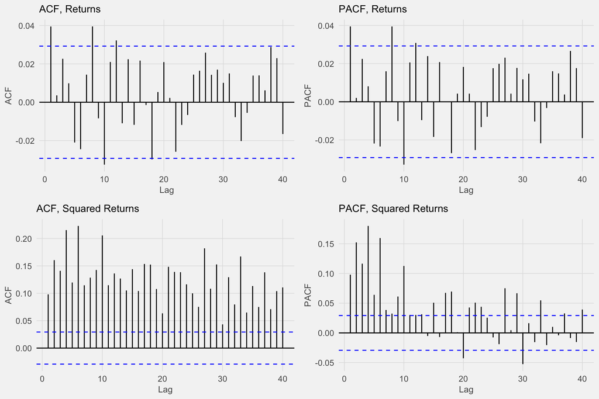

```
ADF statistic, returns: -15.47 (p < 0.01).   Jarque-Bera p < 0.001.
```

```
Ljung-Box, returns, lag 10 / 20: p = 0.0022 / 0.0008.   Squared returns: p < 0.001 / < 0.001.
```

```
Engle ARCH-LM test, 12 lags: statistic 548.2, p < 0.001.
```

The returns are stationary (ADF −15.5) and nearly uncorrelated: the first-order autocorrelation is 0.04, and only five of the first forty autocorrelations lie outside the 95% band, though the Ljung-Box test rejects independence at lag 10 (p = 0.002) because of the lag-one value. The squared returns are a different matter. Their autocorrelation is 0.10 at lag one, 0.16 at lag two and 0.22 at lag four, all forty lags are outside the band, and the Ljung-Box p-values are below 0.001. Engle’s Lagrange-multiplier test for ARCH effects at twelve lags gives a statistic of 548 against a 5% critical value of 21. The variance of the return is predictable from its past even though the return itself is not, which is the condition a GARCH model is built for.

## Mean Equation

Before the variance is modelled, the small autocorrelation in the returns is removed with an ARMA model so that the variance model is applied to innovations.

Five Lowest-AICc ARMA Orders for the Returns

| p | q | AIC | AICc | BIC |
| --- | --- | --- | --- | --- |
| 1 | 0 | 3232.05 | 3232.06 | 3251.28 |
| 0 | 1 | 3232.08 | 3232.09 | 3251.31 |
| 1 | 1 | 3233.84 | 3233.85 | 3259.47 |
| 2 | 0 | 3234.03 | 3234.04 | 3259.67 |
| 0 | 2 | 3234.07 | 3234.07 | 3259.70 |

```
Lowest BIC: ARMA(0,0), BIC 3249.88.
```

```
AR(1): coefficient 0.0395 (s.e. 0.0149), mean 0.0039 (s.e. 0.0054). auto.arima selects ARMA(1,0).
```

```
Residuals: Ljung-Box p at lag 10 / 20 = 0.016 / 0.004.   Squared residuals: p < 0.001 / < 0.001.
```

AIC and AICc select `AR(1)` and `MA(1)` within 0.03 of each other; BIC selects white noise, `ARMA(0,0)`, since the autocorrelation being modelled is 0.04. `auto.arima` selects `AR(1)`, which is used as the mean equation in every variance model below. Its coefficient is 0.040 with a standard error of 0.015. The residuals still show some autocorrelation at lags 8 to 20 (Ljung-Box p = 0.016 at lag 10), which is small in size and is left; their squares are as strongly autocorrelated as the raw squared returns.

## Variance Equation

### Model Selection

Nine variance specifications are estimated jointly with the `AR(1)` mean by maximum likelihood: `ARCH(1)` and `ARCH(4)`, in which the variance depends only on recent squared innovations; `GARCH(1,1)`, `GARCH(1,2)` and `GARCH(2,1)` with normal innovations; `GARCH(1,1)` with Student-t innovations, which allows the heavy tails found above; `GARCH(1,1)` with skewed-t innovations; and two asymmetric models with Student-t innovations, `GJR-GARCH(1,1)` (Glosten et al. 1993), in which a negative innovation adds a separate term to the variance, and `EGARCH(1,1)`, which models the log variance. Persistence is the sum of the ARCH and GARCH coefficients for the symmetric models, and the equivalent quantity for the asymmetric ones; the closer it is to one, the longer a shock to the variance lasts.

Variance Specifications, AR(1) Mean; Information Criteria per Observation

| Model | Parameters | Log-likelihood | AIC | BIC | Persistence |
| --- | --- | --- | --- | --- | --- |
| ARCH(1), normal | 4 | -1553.1 | 0.6940 | 0.6997 | 0.1682 |
| ARCH(4), normal | 7 | -1332.7 | 0.5971 | 0.6071 | 0.4995 |
| GARCH(1,1), normal | 5 | -1150.8 | 0.5152 | 0.5223 | 0.9955 |
| GARCH(1,2), normal | 6 | -1150.2 | 0.5153 | 0.5239 | 0.9956 |
| GARCH(2,1), normal | 6 | -1149.9 | 0.5152 | 0.5238 | 0.9954 |
| GARCH(1,1), Student-t | 6 | -1057.6 | 0.4741 | 0.4826 | 0.9960 |
| GARCH(1,1), skewed-t | 7 | -1054.6 | 0.4732 | 0.4832 | 0.9962 |
| GJR-GARCH(1,1), Student-t | 7 | -1047.7 | 0.4701 | 0.4801 | 0.9955 |
| EGARCH(1,1), Student-t | 7 | -1047.5 | 0.4700 | 0.4800 | 0.9932 |

### Diagnostics

```
GARCH(1,1), Student-t
```

```
Log-likelihood -1057.6   AIC 0.4741   BIC 0.4826 (per observation)   persistence 0.9960   unconditional daily s.d. 0.377%
Standardised residuals: Ljung-Box p at lag 10 / 20 = 0.204 / 0.356;  squared: 0.840 / 0.957;  ARCH-LM(12) p = 0.910;  kurtosis 5.13
```

| Coefficient | Estimate | Std. Error | t | p |
| --- | --- | --- | --- | --- |
| mu | -0.0020 | 0.0042 | -0.47 | 0.6383 |
| ar1 | 0.0372 | 0.0148 | 2.51 | 0.0122 |
| omega | 0.0006 | 0.0002 | 3.23 | 0.0013 |
| alpha1 | 0.0452 | 0.0046 | 9.89 | 0.0000 |
| beta1 | 0.9508 | 0.0045 | 212.31 | 0.0000 |
| shape | 7.4333 | 0.7570 | 9.82 | 0.0000 |

```
GJR-GARCH(1,1), Student-t
```

```
Log-likelihood -1047.7   AIC 0.4701   BIC 0.4801 (per observation)   persistence 0.9955   unconditional daily s.d. 0.341%
Standardised residuals: Ljung-Box p at lag 10 / 20 = 0.262 / 0.383;  squared: 0.936 / 0.994;  ARCH-LM(12) p = 0.971;  kurtosis 5.08
```

| Coefficient | Estimate | Std. Error | t | p |
| --- | --- | --- | --- | --- |
| mu | -0.0001 | 0.0042 | -0.03 | 0.9796 |
| ar1 | 0.0392 | 0.0148 | 2.65 | 0.0081 |
| omega | 0.0005 | 0.0001 | 3.64 | 0.0003 |
| alpha1 | 0.0579 | 0.0050 | 11.52 | 0.0000 |
| beta1 | 0.9557 | 0.0021 | 461.98 | 0.0000 |
| gamma1 | -0.0362 | 0.0080 | -4.55 | 0.0000 |
| shape | 7.6406 | 0.7967 | 9.59 | 0.0000 |

```
Likelihood-ratio test, GJR against symmetric GARCH: statistic 19.84, p < 0.001.
```

Sign-Bias Tests on Standardised Residuals

| Test | GARCH(1,1) p | GJR-GARCH(1,1) p |
| --- | --- | --- |
| Sign Bias | 0.214 | 0.310 |
| Negative Sign Bias | 0.018 | 0.054 |
| Positive Sign Bias | 0.337 | 0.702 |
| Joint Effect | 0.075 | 0.273 |

Both models pass every test on the standardised residuals: no autocorrelation in the residuals or their squares at lags 10 or 20, and no remaining ARCH effect (LM p-values of 0.91 and 0.97). The standardised residuals have kurtosis of about 5, which the Student-t with 7.4 to 7.6 degrees of freedom accommodates. The models differ on asymmetry. In the symmetric model the negative-sign-bias test rejects at p = 0.018: the variance responds to the sign of the previous innovation in a way the model does not capture. The GJR model’s asymmetry coefficient is −0.036 with a standard error of 0.008, the likelihood-ratio test rejects the symmetric model with p < 0.001, and the sign-bias tests no longer reject jointly (p = 0.27).

The sign of the asymmetry is the reverse of what is found in equity markets. In the GJR model the coefficient on a squared innovation is $\alpha$ when the innovation is positive and $\alpha + \gamma$ when it is negative. Here $\alpha = 0.058$ and $\gamma = -0.036$, so a positive innovation, a rise in the dollar, adds 0.058 times its square to next day’s variance, and a fall in the dollar adds 0.022 times its square. Dollar appreciations are the larger source of volatility. This fits the dollar’s role in the sample: it rises when investors leave riskier assets, in the autumn of 2008, in the spring of 2020 and during 2022, and those are the periods in which its volatility is highest.

The retained model, with $r_t$ the daily log return in %, $\varepsilon_t$ the innovation, $\sigma_t^2$ its conditional variance and $I_{t-1} = 1$ when $\varepsilon_{t-1} < 0$, is

$$r_t = -0.0001 + 0.039\, r_{t-1} + \varepsilon_t, \qquad \varepsilon_t = \sigma_t z_t, \quad z_t \sim t_{7.6},$$

$$\sigma_t^2 = 0.0005 + \left(0.058 - 0.036\, I_{t-1}\right)\varepsilon_{t-1}^2 + 0.956\, \sigma_{t-1}^2.$$

Persistence is 0.9955, so half of a shock to the variance remains after 155 trading days. The unconditional daily standard deviation implied by the model is 0.34%.

## Conditional Volatility

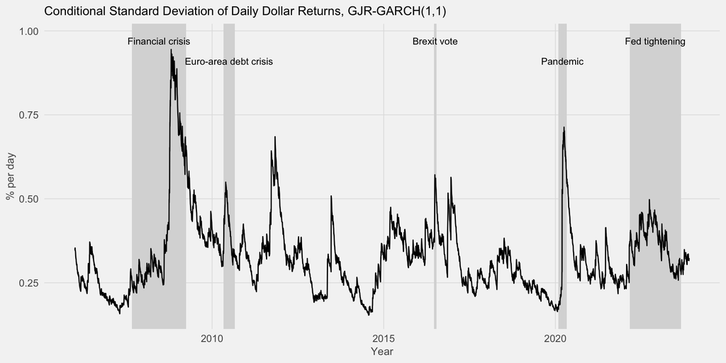

Conditional Volatility in Five Episodes; Full-Sample Median 0.307%, 10th and 90th Percentiles 0.209% and 0.452%

| Episode | Period | Mean σ, % | Peak σ, % | Peak date |
| --- | --- | --- | --- | --- |
| Financial crisis | Sep 2007 to Mar 2009 | 0.434 | 0.945 | 23 Oct 2008 |
| Euro-area debt crisis | May 2010 to Aug 2010 | 0.413 | 0.550 | 26 May 2010 |
| Brexit vote | Jun 2016 to Jul 2016 | 0.496 | 0.572 | 28 Jun 2016 |
| Pandemic | Feb 2020 to Apr 2020 | 0.445 | 0.713 | 02 Apr 2020 |
| Fed tightening | Mar 2022 to Aug 2023 | 0.368 | 0.498 | 27 Sep 2022 |

The estimated conditional standard deviation has a median of 0.31% a day and ranges from 0.15% in July 2014 to 0.95% on 23 October 2008. The five shaded episodes are the periods the visualisation page identified as dollar shocks. The financial crisis is in a class of its own: the five highest readings in the sample all fall between 23 October and 13 November 2008, the peak is three times the median, and the episode’s mean of 0.43% a day is close to the sample’s 90th percentile of 0.45%. The pandemic peak, 0.71% on 2 April 2020, is the second-highest cluster. The 2010 euro-area episode, the week after the Brexit vote and the 2022–2023 tightening all raised volatility to about 0.5 to 0.57% at their peaks, one and a half to two times the median, and the tightening episode, though long, averaged only 0.37%. Two peaks outside the shaded windows are also visible: 0.69% on 2 November 2011, in the second phase of the euro-area crisis, and 0.51% on 21 June 2013, during the bond-market reaction to the Federal Reserve’s tapering announcement. The plot also shows the long quiet period from 2012 to 2019, in which volatility exceeded 0.4% on 11% of days.

## Out-of-Sample Evaluation

The variance is not observed, so a volatility forecast is evaluated against a proxy, here the squared return, using two loss functions: mean squared error, and the QLIKE loss $\log\sigma^2 + r^2/\sigma^2$, which is robust to the noise in the proxy and penalises under-prediction of variance more than over-prediction (Patton 2011). Three GARCH models are re-estimated every 250 trading days on a moving window of 2,500 days and used to forecast the next day’s variance, over the last 30% of the sample, 1,346 days from July 2018 to November 2023. They are compared with three methods that need no estimation: the exponentially weighted moving average of squared returns with decay 0.94, the RiskMetrics convention; the variance of the previous 22 returns; and the constant variance of the training period.

One-Day-Ahead Variance Forecasts, Jul 2018 to Nov 2023, 1346 Days

| Method | MSE | QLIKE |
| --- | --- | --- |
| GARCH(1,1), normal | 0.0460 | -1.3992 |
| GARCH(1,1), Student-t | 0.0460 | -1.3996 |
| GJR-GARCH(1,1), Student-t | 0.0455 | -1.4095 |
| EWMA, decay 0.94 | 0.0458 | -1.3907 |
| 22-day rolling variance | 0.0474 | -1.3541 |
| Constant variance | 0.0498 | -1.2596 |

Value-at-Risk Exceedances and Coverage Tests

| Model | VaR level | Expected | Actual | Kupiec p | Christoffersen p |
| --- | --- | --- | --- | --- | --- |
| GARCH(1,1), normal | 1% | 13 | 19 | 0.153 | 0.195 |
| GARCH(1,1), normal | 5% | 67 | 55 | 0.113 | 0.154 |
| GARCH(1,1), Student-t | 1% | 13 | 11 | 0.486 | 0.717 |
| GARCH(1,1), Student-t | 5% | 67 | 59 | 0.289 | 0.396 |
| GJR-GARCH(1,1), Student-t | 1% | 13 | 11 | 0.486 | 0.717 |
| GJR-GARCH(1,1), Student-t | 5% | 67 | 60 | 0.353 | 0.474 |

The value-at-risk tests ask whether the forecast distribution’s 1% and 5% quantiles are exceeded at the right frequency and whether exceedances are independent. All three models pass both tests at both levels. The normal model comes closest to failing at 1%, with 19 exceedances against 13.5 expected, the usual consequence of a thin-tailed distribution; the two Student-t models have 11 exceedances each. At 5% all three models are slightly conservative, with 55 to 60 exceedances against 67 expected.

## Forecast

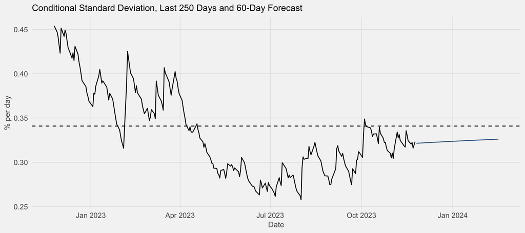

```
Forecast conditional s.d.: day 1 0.322%, day 20 0.323%, day 60 0.326%; last estimated value 0.323%; unconditional 0.341%. Annualised day-1 forecast: 5.1%.
```

At the end of the sample the conditional standard deviation is 0.32% a day, slightly below the model’s unconditional level of 0.34%. The forecast rises toward the unconditional level along the persistence, from 0.322% on the first day to 0.326% on the sixtieth; with a half-life of 155 days the convergence is slow. The forecast carries no information about direction. It says that the dollar in late 2023 was in a period of ordinary volatility, about 5% a year, and that absent a new shock it would stay there. The dashed line is the unconditional standard deviation.

## The Federal Funds Rate and Dollar Volatility

EGARCH(1,1) with Student-t Innovations and Federal Funds Rate Terms in the Variance Equation, 2006–2023

| Variance regressor | Log-likelihood | AIC | BIC | Coefficient (s.e.) | LR test p |
| --- | --- | --- | --- | --- | --- |
| EGARCH(1,1), no regressor | -1027.1 | 0.4668 | 0.4770 |  |  |
| FFR level | -1027.1 | 0.4673 | 0.4789 | 0.0000 (0.0008) | 0.987 |
| \|Change in FFR\| | -1023.9 | 0.4659 | 0.4774 | 0.0227 (0.0125) | 0.012 |
| Both | -1023.0 | 0.4659 | 0.4789 | -0.0011 (0.0012); 0.0301 (0.0160) | 0.017 |

```
In the |change| model beta = 0.9918. A month with a 0.25-point change raises the conditional standard deviation by 5.7% after 21 trading days; a 0.75-point change by 17.9%.
```

The variance regressors are placed in an `EGARCH(1,1)` rather than the GJR model because `rugarch` constrains a GJR variance regressor to be non-negative, which would rule out a negative effect of the rate level before it was tested; the two models fit equally well on the shorter sample, with log-likelihoods within 0.1. The level of the policy rate adds nothing to the daily variance equation: its coefficient is zero to four decimals. The size of the month’s rate change does: its coefficient is 0.023 with a standard error of 0.013, the likelihood-ratio test rejects the model without it at p = 0.012, and AIC falls, though BIC, which penalises the extra parameter more, rises slightly. Because the EGARCH persistence is 0.99, a regressor that stays on for a month compounds: a month in which the rate moved by 0.25 points raises the conditional standard deviation by about 6% over the month, and a 0.75-point month by about 18%; the largest monthly-average changes in 2022 were 0.65 and 0.70 points, since the monthly average smooths the 0.75-point decisions of that year.

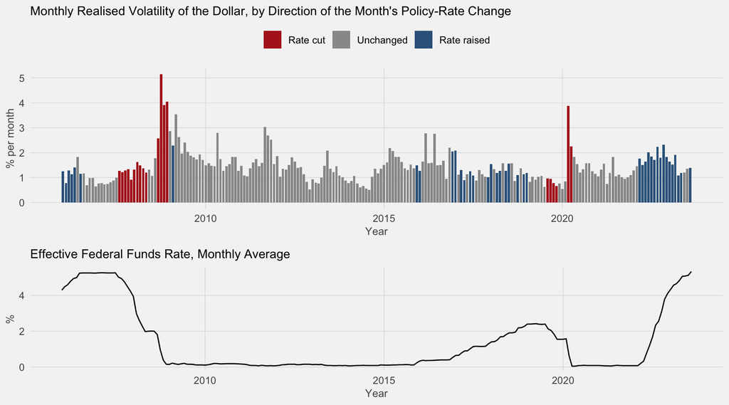

Realised Volatility and Return by Type of Month; a Change of More than 0.05 Points Counts as a Move

| Type | Months | Mean RV, % | Median RV, % | Mean return, % |
| --- | --- | --- | --- | --- |
| Rate cut | 20 | 1.908 | 1.330 | 0.337 |
| Unchanged | 152 | 1.382 | 1.343 | 0.063 |
| Rate raised | 40 | 1.484 | 1.394 | 0.029 |

```
Correlation of monthly realised volatility with the FFR level: -0.230; with the absolute change in the FFR: 0.397. Welch t-test, months with a change against months without: p = 0.014.
```

Monthly Regressions, 212 Months; Newey-West Standard Errors with 6 Lags

| Regression | R2 | FFR level | \|Change in FFR\| | Lagged log RV |
| --- | --- | --- | --- | --- |
| log RV on FFR level | 0.061 | -0.055 (0.025), p 0.027 |  |  |
| log RV on \|change\| | 0.107 |  | 0.800 (0.254), p 0.002 |  |
| log RV on both | 0.226 | -0.080 (0.020), p < 0.001 | 1.029 (0.211), p < 0.001 |  |
| log RV on both and lagged log RV | 0.561 | -0.035 (0.010), p < 0.001 | 0.597 (0.158), p < 0.001 | 0.623 (0.066), p < 0.001 |

Granger-Causality p-values, Monthly VAR of log Realised Volatility and the Change in the FFR

| Lags | FFR change causes volatility | Volatility causes FFR change |
| --- | --- | --- |
| 1 | 0.387 | 0.075 |
| 2 | 0.744 | 0.002 |
| 3 | 0.773 | 0.008 |

Two qualifications apply. The monthly average rate is not a measure of policy surprises; a rate change that was fully anticipated moves the dollar little on the day it is made, and the measure used here does not distinguish anticipated from unanticipated moves. And the daily-frequency effect, while statistically supported, is modest against the model’s own dynamics: a 0.25-point month adds about 6% to the conditional standard deviation, whereas the 2008 crisis tripled it.

## The S&P 500

The same questions are asked of the stock market, using the tools of the course: log returns, the ACF and PACF of the returns and their squares, an `AR(p)`-`ARCH(p)` or `GARCH(1,1)` model estimated with `garchFit` from the `fGarch` package, the standardised-residual tests, and a plot of the conditional variance. The series is `SP500`, the daily closing level of the index, from 23 September 2013 to 20 September 2023, the ten years FRED provides, giving 2,515 daily log returns in %.

### Returns

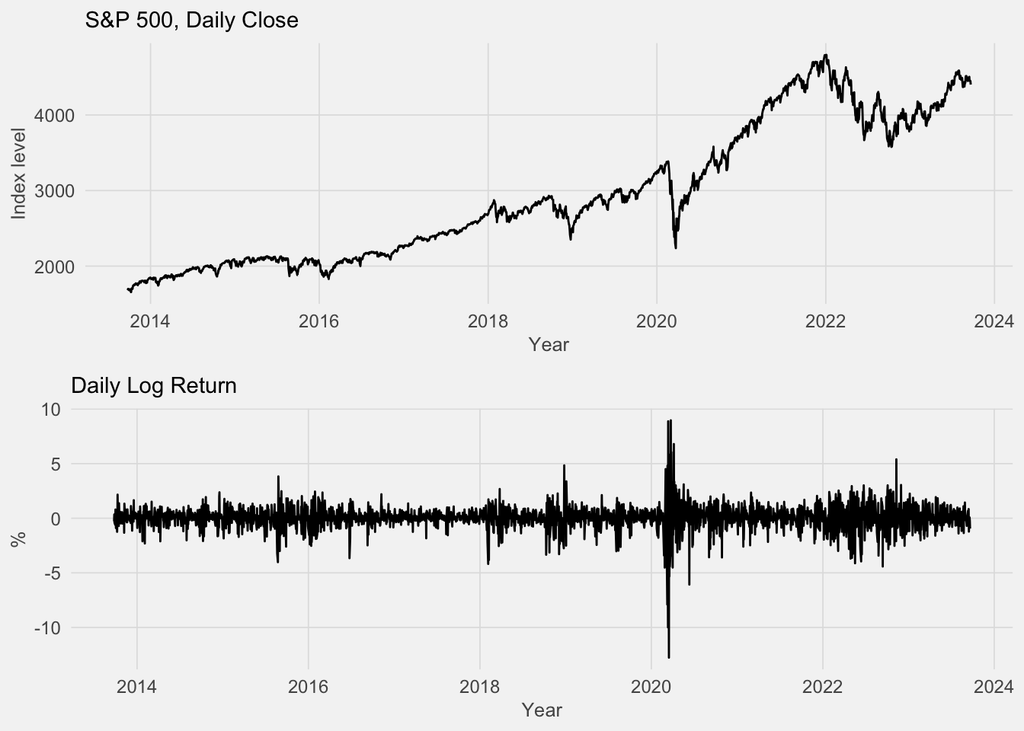

S&P 500 Daily Log Returns, 2013–2023

| Statistic | Value |
| --- | --- |
| Observations | 2,515 |
| Mean, % per day | 0.0378 |
| Standard deviation, % per day | 1.119 |
| Annualised standard deviation, % | 17.8 |
| Excess kurtosis | 16.2 |
| Minimum, % | -12.77 on 16 Mar 2020 |
| Maximum, % | 8.97 on 24 Mar 2020 |

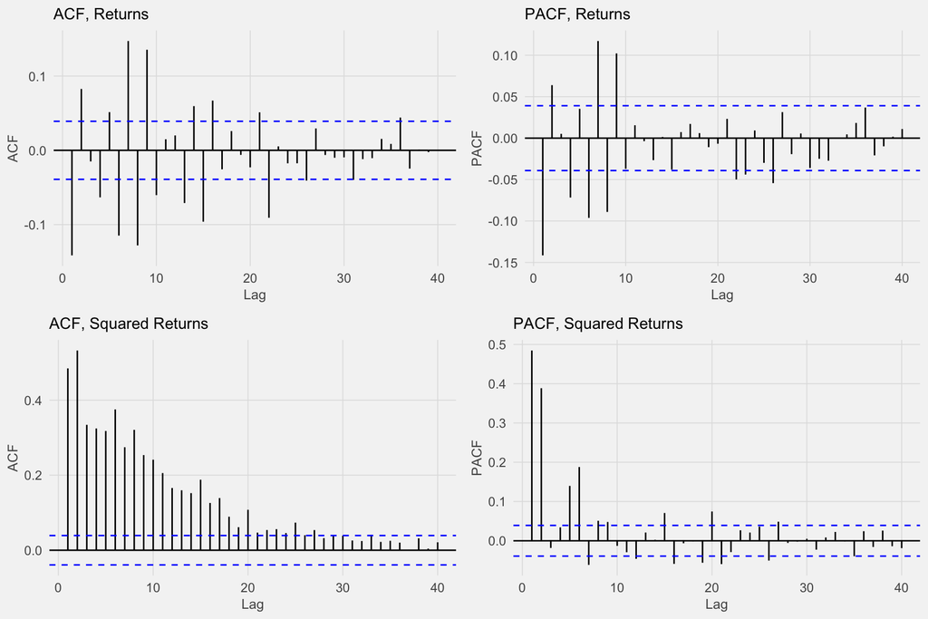

```
Ljung-Box, returns, lag 10: p < 0.001.   Squared returns, lag 10: p < 0.001.   ARCH-LM test, 12 lags: statistic 985.5, p < 0.001.
```

The index rose from 1,702 to 4,402 over the decade. The returns have a mean of 0.04% a day and a standard deviation of 1.12%, 17.8% a year, more than three times the dollar’s, and excess kurtosis of 16, driven by March 2020: the largest fall, −12.8% on 16 March 2020, and the largest rise, +9.0% on 24 March 2020, are eight days apart. The returns themselves have a small negative autocorrelation at lag one, −0.14, and the squared returns are strongly autocorrelated, 0.49 at lag one and 0.53 at lag two, with the PACF of the squares showing two large spikes and then small values. That pattern, white-noise-like returns with an autoregressive structure in the squares, is the signature of ARCH effects described in the lecture, and the LM test confirms it with a statistic of 986.

### Model

The mean is `AR(1)`, the order `auto.arima` selected for the dollar and adequate here for a lag-one autocorrelation of −0.14. Six variance specifications are estimated by maximum likelihood with normal innovations: `ARCH(1)`, `ARCH(2)` and `ARCH(4)`, which the PACF of the squares suggests, and `GARCH(1,1)`, `GARCH(1,2)` and `GARCH(2,1)`.

Variance Specifications for the S&P 500, Normal Innovations; Information Criteria per Observation

| Model | Parameters | Log-likelihood | AIC | BIC |
| --- | --- | --- | --- | --- |
| AR(1)-ARCH(1) | 4 | -3472.1 | 2.7643 | 2.7735 |
| AR(1)-ARCH(2) | 5 | -3330.7 | 2.6526 | 2.6642 |
| AR(1)-ARCH(4) | 7 | -3214.4 | 2.5618 | 2.5780 |
| AR(1)-GARCH(1,1) | 5 | -3174.3 | 2.5282 | 2.5398 |
| AR(1)-GARCH(1,2) | 6 | -3174.5 | 2.5292 | 2.5432 |
| AR(1)-GARCH(2,1) | 6 | -3174.5 | 2.5292 | 2.5431 |

AR(1)-GARCH(1,1), Normal Innovations

| Coefficient | Estimate | Std. Error | t | p |
| --- | --- | --- | --- | --- |
| mu | 0.0834 | 0.0142 | 5.86 | 0.0000 |
| ar1 | -0.0687 | 0.0221 | -3.10 | 0.0019 |
| omega | 0.0391 | 0.0059 | 6.63 | 0.0000 |
| alpha1 | 0.2025 | 0.0218 | 9.29 | 0.0000 |
| beta1 | 0.7688 | 0.0209 | 36.73 | 0.0000 |

Standardised Residual Tests, AR(1)-GARCH(1,1)

| Test | Statistic | p-value |
| --- | --- | --- |
| Jarque-Bera, R | 700.59 | < 0.001 |
| Ljung-Box, R, Q(10) | 8.23 | 0.607 |
| Ljung-Box, R, Q(20) | 19.33 | 0.501 |
| Ljung-Box, R², Q(10) | 8.63 | 0.567 |
| Ljung-Box, R², Q(20) | 13.73 | 0.844 |
| LM ARCH, 12 lags | 10.32 | 0.588 |

```
With Student-t innovations: AIC 2.4656, BIC 2.4796, estimated degrees of freedom 5.6.
```

Each additional ARCH lag improves the fit, from `ARCH(1)` to `ARCH(4)` the log-likelihood rises by 258, and `GARCH(1,1)` improves on `ARCH(4)` by a further 40 points with two fewer parameters, because its lagged-variance term stands in for a long series of ARCH lags. Adding a second ARCH or GARCH term changes the likelihood by less than a point. `AR(1)-GARCH(1,1)` is retained. All five coefficients are significant. The model is

$$r_t = 0.083 - 0.069\, r_{t-1} + y_t, \qquad y_t = \sigma_t \varepsilon_t, \qquad \sigma_t^2 = 0.039 + 0.203\, y_{t-1}^2 + 0.769\, \sigma_{t-1}^2.$$

The standardised residuals pass the Ljung-Box tests on R and R² and the LM ARCH test: the model has removed the autocorrelation in the squares. They fail the Jarque-Bera test, as in the lecture’s GNP example, because the innovations have heavier tails than the normal distribution; re-estimating with Student-t innovations lowers the AIC and puts the degrees of freedom at 5.6, without changing the variance coefficients materially. Persistence, $\alpha_1 + \beta_1$, is 0.971, lower than the dollar’s 0.996: a shock to stock-market volatility decays with a half-life of 24 trading days, against 155 for the dollar. The ARCH coefficient of 0.20 is three and a half times the dollar’s, so the S&P responds to a single day’s shock much more sharply and forgets it much faster.

### Conditional Volatility

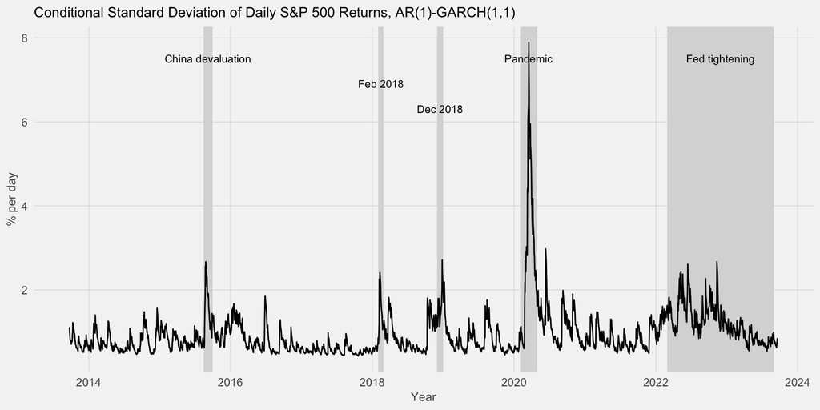

Conditional Volatility in Five Episodes; Full-Sample Median 0.79%

| Episode | Period | Mean σ, % | Peak σ, % | Peak date |
| --- | --- | --- | --- | --- |
| China devaluation | Aug 2015 to Sep 2015 | 1.54 | 2.67 | 27 Aug 2015 |
| Feb 2018 | Feb 2018 to Feb 2018 | 1.53 | 2.41 | 09 Feb 2018 |
| Dec 2018 | Dec 2018 to Dec 2018 | 1.64 | 2.71 | 27 Dec 2018 |
| Pandemic | Feb 2020 to Apr 2020 | 3.03 | 7.89 | 17 Mar 2020 |
| Fed tightening | Mar 2022 to Aug 2023 | 1.22 | 2.67 | 11 Nov 2022 |

The conditional standard deviation has a median of 0.79% a day. Its peak, 7.9% on 17 March 2020, is ten times the median; the dollar’s 2008 peak was three times its median. The pandemic dominates the decade, with the episode averaging 3.0% a day. The other spikes are the August 2015 devaluation of the Chinese yuan, the volatility spike of February 2018, the December 2018 sell-off, and the 2022 tightening, in which volatility averaged 1.2% and peaked at 2.7% in November 2022. Between the episodes the S&P spent 2017 at the lowest volatility in the sample, 0.43% a day in October 2017.

### The Federal Funds Rate

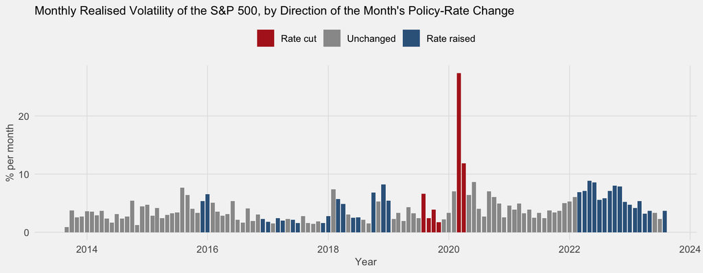

S&P 500 Realised Volatility by Type of Month, 2013–2023

| Type | Months | Mean RV, % | Median RV, % |
| --- | --- | --- | --- |
| Rate cut | 6 | 8.98 | 5.25 |
| Unchanged | 81 | 3.58 | 3.32 |
| Rate raised | 33 | 4.86 | 5.22 |

```
Correlation of monthly realised volatility with |change in FFR|: 0.652; with the FFR level: 0.015.  Welch t-test, months with a change against months without: p = 0.045.
```

```
Regression of log RV on |change in FFR| and FFR level, 120 months, R² = 0.27: |change| 1.86 (s.e. 0.28, p < 0.001); level -0.057 (s.e. 0.033, p 0.088).
```

The relationship found for the dollar holds for the stock market and is stronger. Over the 120 months from October 2013 to August 2023, monthly realised volatility averages 3.6% in the 81 months the policy rate was unchanged, 4.9% in the 33 months it was raised and 9.0% in the six months it was cut; the cuts are the 2019 easing and March–April 2020. The correlation between realised volatility and the size of the month’s rate change is 0.65, against 0.40 for the dollar, and in the regression a one-point change is associated with log volatility 1.86 higher, a factor of 6.4, with p below 0.001, while the level of the rate has no significant effect. The stock market, like the dollar, is most volatile in the months the Federal Reserve moves, and most of all when it cuts, because the cuts come in the episodes of financial stress that also drive equity volatility.

## Summary

Retained Model

| Item | Result |
| --- | --- |
| Series | Daily log returns on the broad dollar index, %, 2006–2023, 4,487 observations |
| Mean equation | AR(1), coefficient 0.039 |
| Variance equation | GJR-GARCH(1,1): ω = 0.0005, α = 0.058, γ = −0.036, β = 0.956 |
| Innovation distribution | Student-t, 7.6 degrees of freedom |
| Persistence | 0.9955; half-life 155 trading days |
| Asymmetry | Dollar appreciations add 0.058 × ε² to variance, depreciations 0.022 × ε² |
| Residual tests | No autocorrelation in z or z², no remaining ARCH effect, no sign bias |
| Out-of-sample rank | Lowest MSE and QLIKE of six methods over 1,346 days |
| VaR coverage | 1% and 5% exceedance rates as expected |
| Federal Funds Rate | \|Change in FFR\| significant in the variance equation (LR p = 0.012); level not; volatility Granger-causes FFR changes, not the reverse |
| S&P 500 | AR(1)-GARCH(1,1) normal: α = 0.203, β = 0.769, persistence 0.971; residual tests pass; monthly RV correlation 0.65 with \|ΔFFR\| |

### What the Model Found

Dollar returns are unpredictable in sign and predictable in size. The mean equation explains almost nothing, an autocorrelation of 0.04, while the variance equation is strongly supported: an ARCH-LM statistic of 548 in the raw returns and none in the model’s residuals. The variance is persistent, with a coefficient on lagged variance of 0.956 and a half-life of half a trading year, and heavy-tailed, with innovations that follow a t-distribution with about 7.6 degrees of freedom. The two additions to a basic `GARCH(1,1)` that the data support are the heavy-tailed distribution, worth 93 log-likelihood points, and asymmetry, worth 10. The asymmetry runs opposite to the leverage effect in equities: rises in the dollar raise its volatility more than falls do, which is consistent with the dollar strengthening during flights to safety.

The volatility path reproduces the episodes documented elsewhere on this site. The financial crisis of 2008 produced a peak three times the median and the highest readings in the sample; the pandemic produced the second-highest; the euro-area crisis, the Brexit vote and the 2022–2023 tightening each produced peaks of about 0.5 to 0.57% a day. Between 2012 and 2019 the dollar was quiet.

### Forecasting

The model’s advantage over simpler methods is real but modest. Over the last 1,346 days its one-day variance forecasts beat the RiskMetrics EWMA by 0.02 on QLIKE and a 22-day rolling variance by 0.06, and its value-at-risk quantiles are exceeded at the right frequency. A practitioner who needs a daily volatility estimate for the dollar would lose little with the EWMA and would lose noticeably with a constant variance. The 60-day forecast is a slow drift from 0.32% to 0.33% a day; GARCH forecasts are informative about the level of volatility over the next few weeks and, beyond the half-life, converge to the unconditional level.

### The S&P 500

The stock market shows the same structure with larger numbers. An `AR(1)-GARCH(1,1)` model estimated with `fGarch` passes the Ljung-Box and LM ARCH tests on its standardised residuals; its ARCH coefficient is 0.20 and its persistence 0.97, so equity volatility reacts to a shock three and a half times as strongly as the dollar’s and forgets it six times as fast, with a half-life of 24 days. The March 2020 peak, 7.9% a day, is ten times the median. Monthly equity volatility is 0.65 correlated with the size of the month’s policy-rate change, 35% higher in months the rate is raised and two and a half times higher in months it is cut.

### Limitations

The squared return is a noisy proxy for the variance, and the out-of-sample comparison inherits that noise; realised variance from intraday data would give sharper rankings. The sample contains two regime changes, the 2008 crisis and the 2020 pandemic, and a model with constant parameters fitted across both estimates an average of their dynamics; the rolling re-estimation in the out-of-sample exercise partly addresses this. The Student-t distribution is symmetric, and the skewed-t did not improve on it, so the asymmetry in the data is carried entirely by the variance equation. The mean equation’s residuals retain small autocorrelations at lags 8 to 20 which are not modelled. The policy-rate variable is a monthly average assigned to every day of its month, so the daily variance regressor is a step function and the monthly analysis cannot distinguish a rate change made at the start of a month from one made at the end.

## References

Bollerslev, Tim. 1986. “Generalized Autoregressive Conditional Heteroskedasticity.” *Journal of Econometrics* 31 (3): 307–27. https://doi.org/10.1016/0304-4076(86)90063-1.

Engle, Robert F. 1982. “Autoregressive Conditional Heteroscedasticity with Estimates of the Variance of United Kingdom Inflation.” *Econometrica* 50 (4): 987–1007. https://doi.org/10.2307/1912773.

Galanos, Alexios. 2024. *Rugarch: Univariate GARCH Models*. https://CRAN.R-project.org/package=rugarch.

Glosten, Lawrence R, Ravi Jagannathan, and David E Runkle. 1993. “On the Relation Between the Expected Value and the Volatility of the Nominal Excess Return on Stocks.” *Journal of Finance* 48 (5): 1779–801. https://doi.org/10.1111/j.1540-6261.1993.tb05128.x.

Patton, Andrew J. 2011. “Volatility Forecast Comparison Using Imperfect Volatility Proxies.” *Journal of Econometrics* 160 (1): 246–56. https://doi.org/10.1016/j.jeconom.2010.03.034.